# act_report

### ACT REPORT

We load the final dataset

```python
import pandas as pd

# we load the data from twitter_archive_master.csv in df
df = pd.read_csv('twitter_archive_master.csv')
```

```python
# We check the dataframe
print(df.info())
df.head()
```

```
<class 'pandas.core.frame.DataFrame'>
RangeIndex: 1970 entries, 0 to 1969
Data columns (total 11 columns):
tweet_id              1970 non-null int64
timestamp             1970 non-null object
text                  1970 non-null object
dog_stage             303 non-null object
favorite_count        1970 non-null float64
retweet_count         1970 non-null float64
name                  1350 non-null object
rating_numerator      1970 non-null float64
rating_denominator    1970 non-null float64
image_name            1970 non-null object
image_number          1970 non-null float64
dtypes: float64(5), int64(1), object(5)
memory usage: 169.4+ KB
None
```

|  | tweet_id | timestamp | text | dog_stage | favorite_count | retweet_count | name | rating_numerator | rating_denominator | image_name | image_number |
| --- | --- | --- | --- | --- | --- | --- | --- | --- | --- | --- | --- |
| 0 | 892420643555336193 | 2017-08-01 16:23:56 | This is Phineas. He's a mystical boy. Only eve... | NaN | 39467.0 | 8853.0 | Phineas | 13.0 | 10.0 | DGKD1-bXoAAIAUK.jpg | 1.0 |
| 1 | 892177421306343426 | 2017-08-01 00:17:27 | This is Tilly. She's just checking pup on you.... | NaN | 33819.0 | 6514.0 | Tilly | 13.0 | 10.0 | DGGmoV4XsAAUL6n.jpg | 1.0 |
| 2 | 891815181378084864 | 2017-07-31 00:18:03 | This is Archie. He is a rare Norwegian Pouncin... | NaN | 25461.0 | 4328.0 | Archie | 12.0 | 10.0 | DGBdLU1WsAANxJ9.jpg | 1.0 |
| 3 | 891689557279858688 | 2017-07-30 15:58:51 | This is Darla. She commenced a snooze mid meal... | NaN | 42908.0 | 8964.0 | Darla | 13.0 | 10.0 | DF_q7IAWsAEuuN8.jpg | 1.0 |
| 4 | 891327558926688256 | 2017-07-29 16:00:24 | This is Franklin. He would like you to stop ca... | NaN | 41048.0 | 9774.0 | Franklin | 12.0 | 10.0 | DF6hr6BUMAAzZgT.jpg | 2.0 |

```python
# we load the data from twitter-archive-enhanced.csv in df
df_orig = pd.read_csv('twitter-archive-enhanced.csv')
```

```python
# We chech the dataframe
print(df_orig.info())
df_orig.head()
```

```
<class 'pandas.core.frame.DataFrame'>
RangeIndex: 2356 entries, 0 to 2355
Data columns (total 17 columns):
tweet_id                      2356 non-null int64
in_reply_to_status_id         78 non-null float64
in_reply_to_user_id           78 non-null float64
timestamp                     2356 non-null object
source                        2356 non-null object
text                          2356 non-null object
retweeted_status_id           181 non-null float64
retweeted_status_user_id      181 non-null float64
retweeted_status_timestamp    181 non-null object
expanded_urls                 2297 non-null object
rating_numerator              2356 non-null int64
rating_denominator            2356 non-null int64
name                          2356 non-null object
doggo                         2356 non-null object
floofer                       2356 non-null object
pupper                        2356 non-null object
puppo                         2356 non-null object
dtypes: float64(4), int64(3), object(10)
memory usage: 313.0+ KB
None
```

|  | tweet_id | in_reply_to_status_id | in_reply_to_user_id | timestamp | source | text | retweeted_status_id | retweeted_status_user_id | retweeted_status_timestamp | expanded_urls | rating_numerator | rating_denominator | name | doggo | floofer | pupper | puppo |
| --- | --- | --- | --- | --- | --- | --- | --- | --- | --- | --- | --- | --- | --- | --- | --- | --- | --- |
| 0 | 892420643555336193 | NaN | NaN | 2017-08-01 16:23:56 +0000 | <a href="http://twitter.com/download/iphone" r... | This is Phineas. He's a mystical boy. Only eve... | NaN | NaN | NaN | https://twitter.com/dog_rates/status/892420643... | 13 | 10 | Phineas | None | None | None | None |
| 1 | 892177421306343426 | NaN | NaN | 2017-08-01 00:17:27 +0000 | <a href="http://twitter.com/download/iphone" r... | This is Tilly. She's just checking pup on you.... | NaN | NaN | NaN | https://twitter.com/dog_rates/status/892177421... | 13 | 10 | Tilly | None | None | None | None |
| 2 | 891815181378084864 | NaN | NaN | 2017-07-31 00:18:03 +0000 | <a href="http://twitter.com/download/iphone" r... | This is Archie. He is a rare Norwegian Pouncin... | NaN | NaN | NaN | https://twitter.com/dog_rates/status/891815181... | 12 | 10 | Archie | None | None | None | None |
| 3 | 891689557279858688 | NaN | NaN | 2017-07-30 15:58:51 +0000 | <a href="http://twitter.com/download/iphone" r... | This is Darla. She commenced a snooze mid meal... | NaN | NaN | NaN | https://twitter.com/dog_rates/status/891689557... | 13 | 10 | Darla | None | None | None | None |
| 4 | 891327558926688256 | NaN | NaN | 2017-07-29 16:00:24 +0000 | <a href="http://twitter.com/download/iphone" r... | This is Franklin. He would like you to stop ca... | NaN | NaN | NaN | https://twitter.com/dog_rates/status/891327558... | 12 | 10 | Franklin | None | None | None | None |

We inspect the final dataframe df for columns related with name, rating numerator and rating denominator.

```python
names = df[df.name.notnull()].name
print(names.size)
names.value_counts()
```

```
1350
```

```
Charlie     11
Cooper      10
Oliver      10
Lucy        10
Penny        9
Tucker       9
Winston      8
Sadie        8
Lola         7
Toby         7
Daisy        7
Bo           6
Koda         6
Bella        6
Jax          6
Stanley      6
Leo          5
Rusty        5
Milo         5
Oscar        5
Chester      5
Dave         5
Buddy        5
Scout        5
Louis        5
Bailey       5
Jerry        4
Oakley       4
Phil         4
Sophie       4
            ..
Rilo         1
Harry        1
Milky        1
Chadrick     1
Tobi         1
Betty        1
William      1
Willie       1
Cali         1
Bowie        1
Tuco         1
Monty        1
Deacon       1
Augie        1
Timison      1
Dug          1
Layla        1
Huck         1
Carbon       1
Anna         1
Autumn       1
Major        1
Mo           1
Furzey       1
Amber        1
Orion        1
Tino         1
Brian        1
Ashleigh     1
Kenny        1
Name: name, Length: 912, dtype: int64
```

```python
df.rating_numerator.value_counts()
```

```
12.00      446
10.00      417
11.00      392
13.00      253
9.00       151
8.00        95
7.00        52
14.00       33
5.00        32
6.00        32
3.00        19
4.00        16
2.00         9
1.00         4
9.75         1
84.00        1
13.50        1
0.00         1
420.00       1
121.00       1
50.00        1
80.00        1
45.00        1
60.00        1
44.00        1
144.00       1
88.00        1
11.26        1
165.00       1
11.27        1
1776.00      1
99.00        1
204.00       1
Name: rating_numerator, dtype: int64
```

```python
df.rating_denominator.value_counts()
```

```
10.0     1955
50.0        3
80.0        2
11.0        2
170.0       1
150.0       1
120.0       1
110.0       1
40.0        1
90.0        1
20.0        1
70.0        1
Name: rating_denominator, dtype: int64
```

**INSIGHT 1:** After filtering the data for tweets that are not replies pr retweets and are related with images we obtain a final dataset of 1970 records instead the 2356 records from the original dataset, so we have 386 records less. We had a difference in two of the records of the original dataset and the dataset that we extracted form Twitter which were retweets, the rest of the records match in the columns that we try.

**INSIGHT 2:** We have collected the data of the names correctly since there are no longer names that begin with a lowercase letter which corresponded to errors, although we only have 1350 records, but after the appropriate checks it seems that it is because in many texts of the tweets there are no describe the name so the rest have been left as null values.

**INSIGHT 3:** The rating numertors and rating denominators now seems correct, we hhave four numerators as decimal. Most ratings are higher than / 10 and some numerators and denominators are disproportionate but are actually correct with respect to the tweet.

We visualizate the columns favorite_count and retwweted_count of the final dataframe

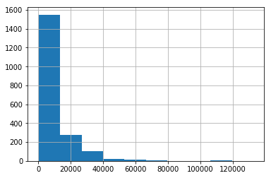

```python
df.favorite_count.hist()
```

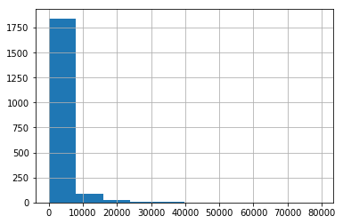

```python
df.retweet_count.hist()
```